# EDA_Retail

## Author: Mo'men Zanatii

### The Sparks Foundation: Data Science & Business Analytics Internship

### Task 3 : Exploratory Data Analysis - Retail (Level - Beginner)

#### Task Statement: As a business manager, try to find out the weak areas where you can work to make more profit. And what all business problems you can derive by exploring the data?

**Importing Packages**

```python
import pandas as pd
import numpy as np
import matplotlib.pyplot as plt
import seaborn as sns
sns.set_style('whitegrid')
import warnings
warnings.filterwarnings('ignore')
```

**Loading the data**

```python
df = pd.read_csv('SampleSuperstore.csv')
```

### *Summary statistics of the data.*

```python
df.head()
```

|  | Ship Mode | Segment | Country | City | State | Postal Code | Region | Category | Sub-Category | Sales | Quantity | Discount | Profit |
| --- | --- | --- | --- | --- | --- | --- | --- | --- | --- | --- | --- | --- | --- |
| 0 | Second Class | Consumer | United States | Henderson | Kentucky | 42420 | South | Furniture | Bookcases | 261.9600 | 2 | 0.00 | 41.9136 |
| 1 | Second Class | Consumer | United States | Henderson | Kentucky | 42420 | South | Furniture | Chairs | 731.9400 | 3 | 0.00 | 219.5820 |
| 2 | Second Class | Corporate | United States | Los Angeles | California | 90036 | West | Office Supplies | Labels | 14.6200 | 2 | 0.00 | 6.8714 |
| 3 | Standard Class | Consumer | United States | Fort Lauderdale | Florida | 33311 | South | Furniture | Tables | 957.5775 | 5 | 0.45 | -383.0310 |
| 4 | Standard Class | Consumer | United States | Fort Lauderdale | Florida | 33311 | South | Office Supplies | Storage | 22.3680 | 2 | 0.20 | 2.5164 |

```python
df.shape
```

```
(9994, 13)
```

```python
df.columns
```

```
Index(['Ship Mode', 'Segment', 'Country', 'City', 'State', 'Postal Code',
       'Region', 'Category', 'Sub-Category', 'Sales', 'Quantity', 'Discount',
       'Profit'],
      dtype='object')
```

```python
df.info()
```

```
<class 'pandas.core.frame.DataFrame'>
RangeIndex: 9994 entries, 0 to 9993
Data columns (total 13 columns):
 #   Column        Non-Null Count  Dtype
---  ------        --------------  -----
 0   Ship Mode     9994 non-null   object
 1   Segment       9994 non-null   object
 2   Country       9994 non-null   object
 3   City          9994 non-null   object
 4   State         9994 non-null   object
 5   Postal Code   9994 non-null   int64
 6   Region        9994 non-null   object
 7   Category      9994 non-null   object
 8   Sub-Category  9994 non-null   object
 9   Sales         9994 non-null   float64
 10  Quantity      9994 non-null   int64
 11  Discount      9994 non-null   float64
 12  Profit        9994 non-null   float64
dtypes: float64(3), int64(2), object(8)
memory usage: 1015.1+ KB
```

```python
df.describe()
```

|  | Postal Code | Sales | Quantity | Discount | Profit |
| --- | --- | --- | --- | --- | --- |
| count | 9994.000000 | 9994.000000 | 9994.000000 | 9994.000000 | 9994.000000 |
| mean | 55190.379428 | 229.858001 | 3.789574 | 0.156203 | 28.656896 |
| std | 32063.693350 | 623.245101 | 2.225110 | 0.206452 | 234.260108 |
| min | 1040.000000 | 0.444000 | 1.000000 | 0.000000 | -6599.978000 |
| 25% | 23223.000000 | 17.280000 | 2.000000 | 0.000000 | 1.728750 |
| 50% | 56430.500000 | 54.490000 | 3.000000 | 0.200000 | 8.666500 |
| 75% | 90008.000000 | 209.940000 | 5.000000 | 0.200000 | 29.364000 |
| max | 99301.000000 | 22638.480000 | 14.000000 | 0.800000 | 8399.976000 |

**Figure out the lentgh of the numerical and categorical data.**

```python
numerical_df = df.select_dtypes(include=['float64', 'int64'])
print(numerical_df)
print("The length of numerical columns is: ",len(numerical_df.columns))
```

```
      Postal Code     Sales  Quantity  Discount    Profit
0           42420  261.9600         2      0.00   41.9136
1           42420  731.9400         3      0.00  219.5820
2           90036   14.6200         2      0.00    6.8714
3           33311  957.5775         5      0.45 -383.0310
4           33311   22.3680         2      0.20    2.5164
...           ...       ...       ...       ...       ...
9989        33180   25.2480         3      0.20    4.1028
9990        92627   91.9600         2      0.00   15.6332
9991        92627  258.5760         2      0.20   19.3932
9992        92627   29.6000         4      0.00   13.3200
9993        92683  243.1600         2      0.00   72.9480

[9994 rows x 5 columns]
The length of numerical columns is:  5
```

```python
categorical_df = df.select_dtypes(include=['object'])
print(categorical_df)
print("The length of numerical columns is: ",len(categorical_df.columns))
```

```
           Ship Mode    Segment        Country             City       State  \
0       Second Class   Consumer  United States        Henderson    Kentucky
1       Second Class   Consumer  United States        Henderson    Kentucky
2       Second Class  Corporate  United States      Los Angeles  California
3     Standard Class   Consumer  United States  Fort Lauderdale     Florida
4     Standard Class   Consumer  United States  Fort Lauderdale     Florida
...              ...        ...            ...              ...         ...
9989    Second Class   Consumer  United States            Miami     Florida
9990  Standard Class   Consumer  United States       Costa Mesa  California
9991  Standard Class   Consumer  United States       Costa Mesa  California
9992  Standard Class   Consumer  United States       Costa Mesa  California
9993    Second Class   Consumer  United States      Westminster  California

     Region         Category Sub-Category
0     South        Furniture    Bookcases
1     South        Furniture       Chairs
2      West  Office Supplies       Labels
3     South        Furniture       Tables
4     South  Office Supplies      Storage
...     ...              ...          ...
9989  South        Furniture  Furnishings
9990   West        Furniture  Furnishings
9991   West       Technology       Phones
9992   West  Office Supplies        Paper
9993   West  Office Supplies   Appliances

[9994 rows x 8 columns]
The length of numerical columns is:  8
```

### Checking missing values

```python
df.isnull().sum()
```

```
Ship Mode       0
Segment         0
Country         0
City            0
State           0
Postal Code     0
Region          0
Category        0
Sub-Category    0
Sales           0
Quantity        0
Discount        0
Profit          0
dtype: int64
```

```python
df.isnull().sum().any()
```

```
False
```

**There's no missing values in the dataset.**

```python
df_states = df['State'].value_counts()
df_sales = df['Sales']
```

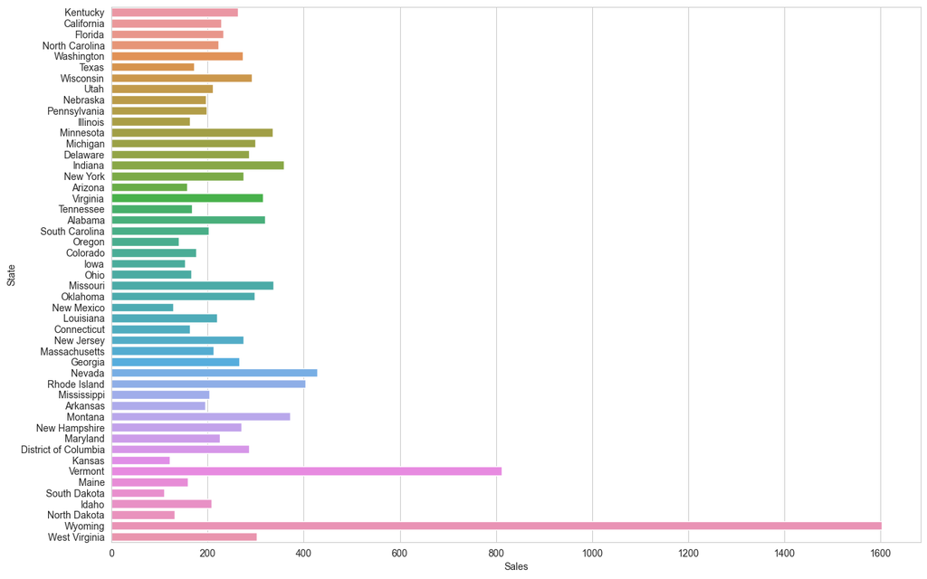

```python
fig, ax = plt.subplots(figsize=(15,10))
sns.barplot(y="State", x="Sales", data=df, ci=None)
plt.show();
```

### The heights of the bars in the above figure represent the average sales values for each state.

```
- As we see Wyoming State having the highest number of sales.
```

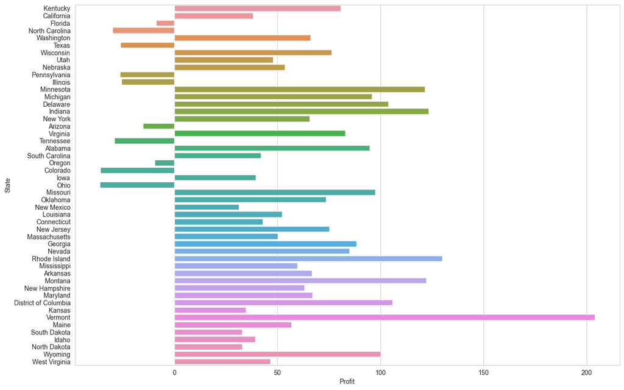

```python
fig, ax = plt.subplots(figsize=(15,10))
sns.barplot(y="State", x="Profit", data=df, ci=None)
plt.show();
```

### As we know the heights of the bars in the above figure represent the average profits values for each state.

```
- As we see Wyoming State having the highest number of sales but not the highest profit.
- Vermont State having the highest profits numbres.
```